# IODS-Final

# Distances

Now we reload the alc dataset and standardize it. Then we take a look at the distances between the variables.

```r
New_alc <- alcdata_

str(New_alc)
```

```
## 'data.frame':    382 obs. of  3 variables:
##  $ G1: int  5 5 7 15 6 15 12 6 16 14 ...
##  $ G2: int  6 5 8 14 10 15 12 5 18 15 ...
##  $ G3: int  6 6 10 15 10 15 11 6 19 15 ...
```

```r
New_alc_scaled <- scale(New_alc) %>% as.data.frame()

str(New_alc_scaled)
```

```
## 'data.frame':    382 obs. of  3 variables:
##  $ G1: num  -1.75 -1.75 -1.15 1.24 -1.45 ...
##  $ G2: num  -1.229 -1.49 -0.708 0.858 -0.186 ...
##  $ G3: num  -0.936 -0.936 -0.0827 0.9841 -0.0827 ...
```

Now we calculate the distances.

```r
# Euclidean distance matrix using set.seed()
set.seed(123)
dist_eu <- dist(New_alc_scaled)
summary(dist_eu)
```

```
##    Min. 1st Qu.  Median    Mean 3rd Qu.    Max.
##  0.0000  0.9571  1.8010  2.0510  2.8610  7.9270
```

This is based on the Euclidean measure. And above you see the summary of the findings. Now we can start the clustering with the amount of 10 clusters. 10 is a safe bet that nothing would go wrong, below I calculate the optimum amount of clusters.

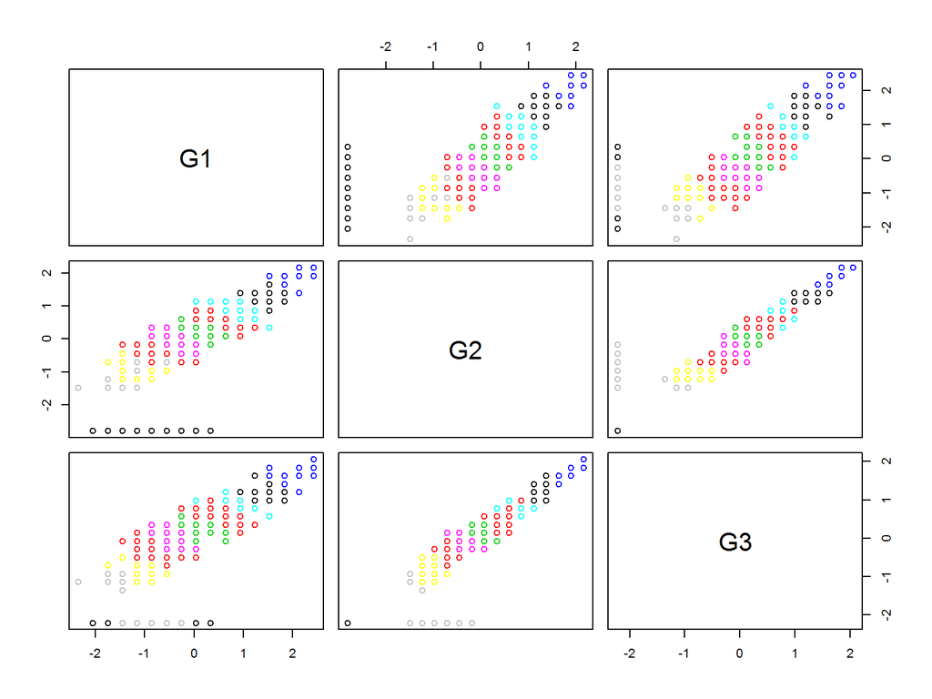

```r
km <-kmeans(dist_eu, centers=10)
pairs(New_alc_scaled, col = km$cluster)
```

Because of the picture being so hard to interpret we want to optimize the amount of clusters so we don’t have to guess it and then we can take a look at the plot again.

# The optimal amount of clusters

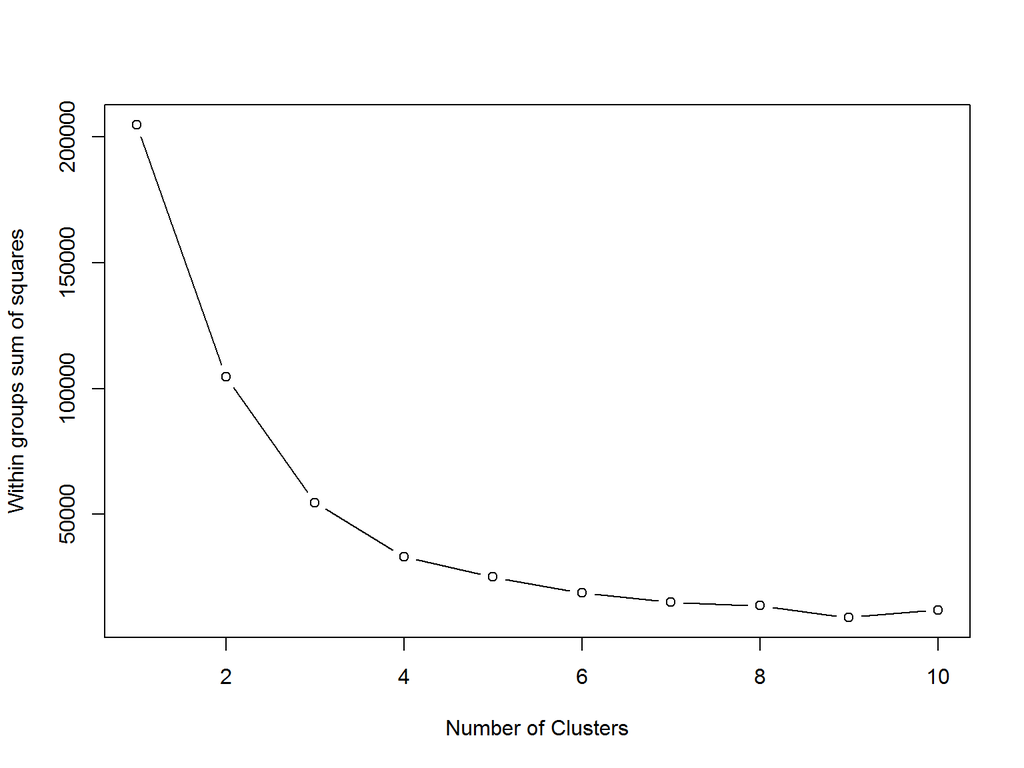

```r
k_max <- 10
wss <- sapply(1:k_max, function(k){kmeans(dist_eu, k)$tot.withinss})
plot(1:k_max, wss, type="b", xlab="Number of Clusters",
  ylab="Within groups sum of squares")
```

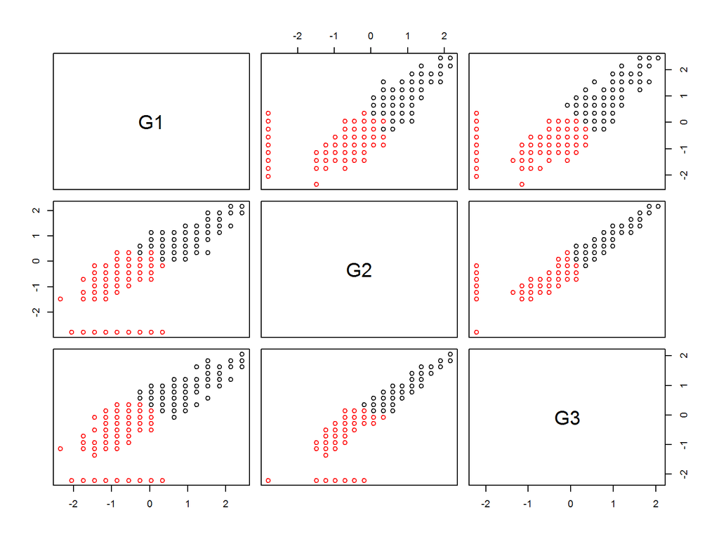

```r
km <-kmeans(dist_eu, centers=2)
pairs(New_alc_scaled, col = km$cluster)
```

Next we perform LDA using the clusters as target classes. We include all the grades in the alc data in the LDA model.

```r
km <-kmeans(dist_eu, centers = 3)
lda.fits <- lda(km$cluster~., data = alcdata_scaled)
lda.fits
```

```
## Call:
## lda(km$cluster ~ ., data = alcdata_scaled)
##
## Prior probabilities of groups:
##         1         2         3
## 0.3089005 0.5026178 0.1884817
##
## Group means:
##           G1         G2 G3_categorymed_low G3_categorymed_high
## 1  1.1952674  1.0900778         0.01694915           0.3559322
## 2 -0.2991435 -0.1518133         0.64583333           0.2083333
## 3 -1.1611945 -1.3816810         0.00000000           0.0000000
##   G3_categoryhigh
## 1       0.6271186
## 2       0.0000000
## 3       0.0000000
##
## Coefficients of linear discriminants:
##                            LD1        LD2
## G1                  -0.7980209  0.5737970
## G2                  -0.6114441 -0.8435012
## G3_categorymed_low  -1.1807020 -3.0284475
## G3_categorymed_high -2.1412320 -1.2163005
## G3_categoryhigh     -2.8887728  0.5876522
##
## Proportion of trace:
##    LD1    LD2
## 0.7721 0.2279
```

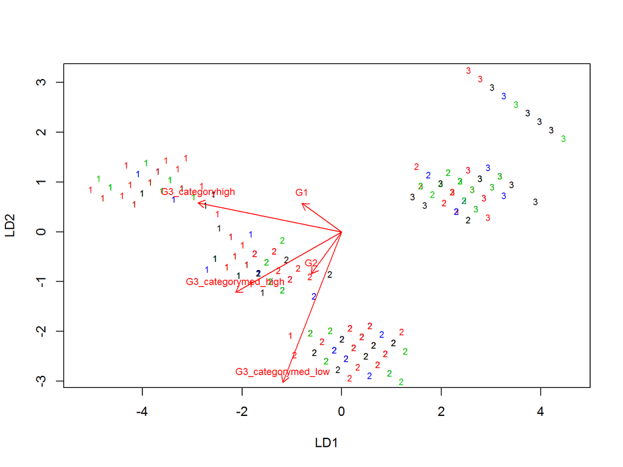

```r
plot(lda.fits, dimen = 2, col = classes)
lda.arrows(lda.fits, myscale = 1)
```

There is quite a large group of number 3 in the top right corner even though the arrows point in the opposite direction.

# Final words

The biggest concern that I have after this analysis is that there is omitted variable bias as I only have the first two grades explaining the final grade. This is not a huge issue in clustering as in clustering the objective is to to group the observations in a way that makes them more similar to each other. On the other hand if this was a real regression model then this would be a lot more problematic.

The omitted variable bias could be fixed with new variables or control variables. They could be for example the wealth of the family or how much alcohol the student consumes.